# Homework Chapter 11

Emily Maloney

March 24, 2019

```r
library(tidyverse)
library(rethinking)
library(brms)
library(knitr)
library(bayesplot)
```

## Chapter 11

### Easy Problems

#### 11E1

An ordered categorical variable is one in which the points on the scale correspond to levels while an unordered categorical variable’s elements cannot be ranked against each other. An example of an ordered categorical variable is grades (A, B, C, D, F), and an example of an unordered categorical variable is sex (Male, Female, Intersex).

#### 11E2

An ordered logistic regression employs a cumulative logit link, which means that it uses the log-cumulative-odds for each of the ordered outcomes - in other words, the log odds of that value or anything below it on the scale. An unordered logistic regression employs a logit link, which is just the log-odds for the specific outcome.

#### 11E3

When count data are zero-inflated, using a model that ignores zero-inflation will tend to induce Type I error.

#### 11E4

An example of a process that might produce over-dispersed counts would be the number of times someone talks in class, because everyone has a different threshold for speaking. An example of a process that might produce under-dispersed counts would be the number of children women have in Scandanavia, because I think the variance would be lower than the expected value.

### Medium Problems

#### 11M1

```r
#make dataset with rating and frequency
d <- tibble(rating = seq(1, 4, by = 1),
               freq = c(12, 36, 7, 41))

#calculate log cum odds and the previous proportion
d <- d %>% mutate(total = sum(freq),
                  cum_sum = cumsum(freq),
                  cum_prop = cum_sum/total,
                  cum_odds = cum_prop/(1-cum_prop),
                  log_cum_odds = log(cum_odds),
                  prev_prop = lag(cum_prop, default = 0))

#make table of log_cum_odds
table <- d %>% select(rating, log_cum_odds)
kable(table)
```

| rating | log_cum_odds |
| --- | --- |
| 1 | -1.9459101 |
| 2 | 0.0000000 |
| 3 | 0.2937611 |
| 4 | Inf |

The log-cumulative-odds for getting a rating 1 is -1.95. For getting a rating of 2, the log-cumulative-odds is 0, and for getting a rating of 3, the log-cumulative-odds is 0.29. The log-cumulative-odds for the rating 4 is infinite because the cumulative probability of the highest value on the scale is 1, so the odds are 1/(0), which is indefinite.

#### 11M2

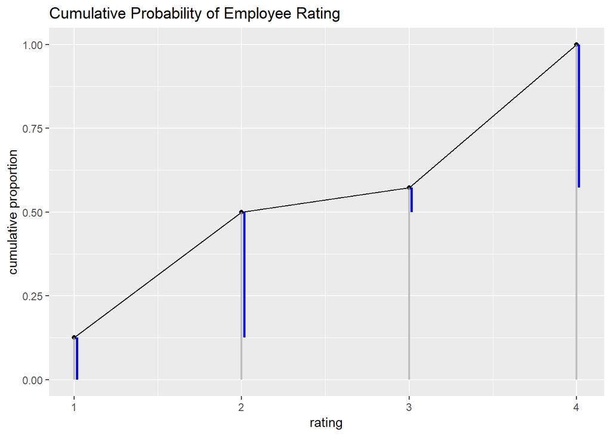

```r
#making plot
ggplot(data = d, mapping = aes(x = rating, y = cum_prop)) +
  geom_line() +
  geom_point() +
  geom_linerange(mapping = aes(ymin = 0,
                               ymax = cum_prop),
                               alpha = 3/4,
                               color = "dark gray",
                               size = 0.75) +
  geom_linerange(mapping = aes(x = rating + .015,
                               ymin = prev_prop,
                               ymax = cum_prop),
                               color = "blue",
                               alpha = 1,
                               size = 1) +
  labs(title = "Cumulative Probability of Employee Rating",
       x = "rating", y = "cumulative proportion")
```

This plot shows the growing cumulative probability for each rating from 1 to 4 in the gray vertical lines. The blue lines are the discrete probability for each rating and represent the likelihood of each rating. As the plot shows, the ratings 2 and 4 have a much higher likelihood than the ratings 1 or 3.

#### 11M3

With probability *d* that secondary process produces 0, *n* equal to the number of trials, and *p* the probability of success, the likelihood of a zero result is:  
$d + (1- d)(1-p)^n$  
and the likelihood of a non-zero result is:  
$(1 - d)(p^y)\binom{n}{y}(1-p)^{(n-y)}$.

To construct this distribution, I simulated each of these processes and then plotted them together, to show how the secondary process inflates the number of zeros in the binomial distribution.

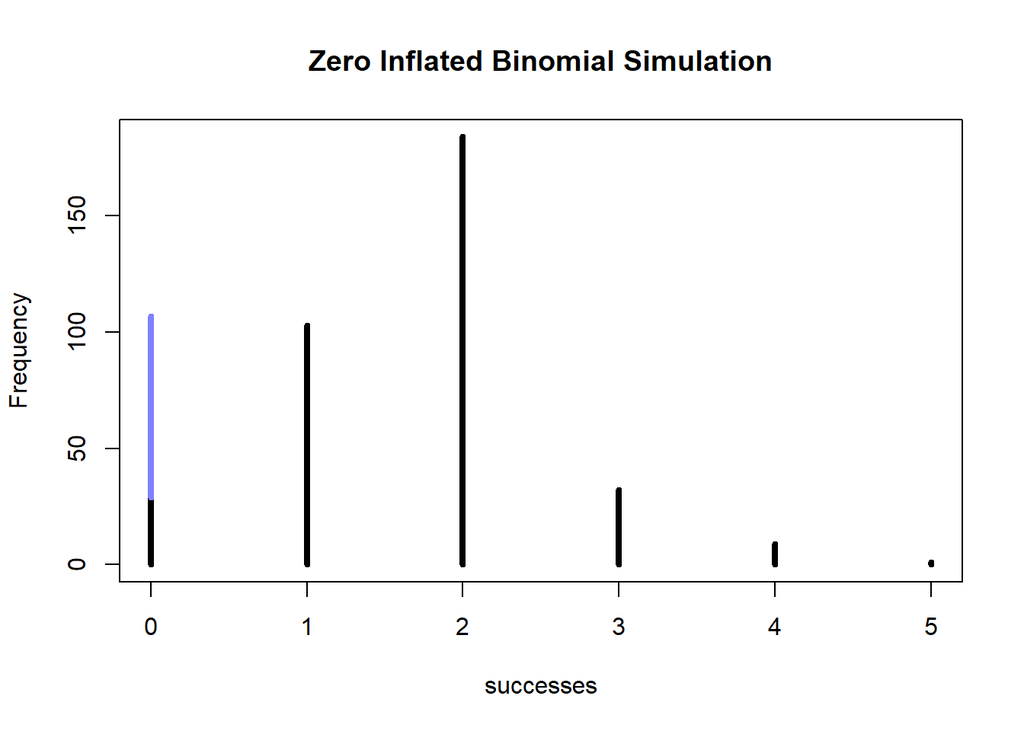

```r
#defining parameters
d <- 0.2
n <- 365
p <- 0.2

#simulate days w/no production
zero_2 <- rbinom(n, 1, d)

#simulate number completed
y <- (1-d)*rbinom(n, 10, p)
y <- as.data.frame(y)

simplehist(y, xlab = "successes", lwd = 4)
zeros_second <- sum(zero_2)
zeros_first <- sum(y == 0 & zero_2 == 0)
zeros_total <- zeros_second + zeros_first
lines(c(0,0), c(zeros_first, zeros_total), lwd = 4, col = rangi2)
title(main = "Zero Inflated Binomial Simulation")
```

In this histogram, the black lines show the typical binomial distribution for the parameters *n* equal to 365 and *p* equal to 0.2, given a trial size of 10. The blue line at 0 represents the number of days in which there were no successes from a secondary process unrelated to the binomial. Including this process inflates the number of expected zeros to even be slightly more than the number of expected ones.

### Hard problems

#### 11H1

```r
#load in data
data("Hurricanes")
h <- Hurricanes

#model with just intercept
h11.1 <- brm(data = h, family = poisson,
             deaths ~ 1,
             prior = c(prior(normal(0, 100), class = Intercept)),
             iter = 3000, warmup = 1000, chains = 4, cores = 4)

#model with femininity predictor
h11.2 <- update(h11.1,  newdata = h, formula = deaths ~ 1 + femininity,
                prior = c(prior(normal(0, 100), class = Intercept),
                          prior(normal(0, 10), class = b)))
#compare estimates
fixef(h11.1) %>% round(digits = 2)
```

```
##           Estimate Est.Error Q2.5 Q97.5
## Intercept     3.03      0.02 2.98  3.07
```

```r
fixef(h11.2) %>% round(digits = 2)
```

```
##            Estimate Est.Error Q2.5 Q97.5
## Intercept      2.50      0.06 2.38  2.62
## femininity     0.07      0.01 0.06  0.09
```

```r
#compare WAIC
waic(h11.1, h11.2)
```

```
##                  WAIC      SE
## h11.1         4446.32 1080.38
## h11.2         4412.84 1003.65
## h11.1 - h11.2   33.48  142.15
```

```r
#weights
model_weights(h11.1, h11.2,
              weights = "waic") %>%
  round(digits = 2)
```

```
## h11.1 h11.2
##     0     1
```

The model including femininity (h11.2) has a lower WAIC and gets all of the model weight when compared to an intercept-only Poisson model of deaths. This suggests that femininity does have some predictive power, but we should check the model predictions to assess how well (or not well) the model accurately fits different storms..

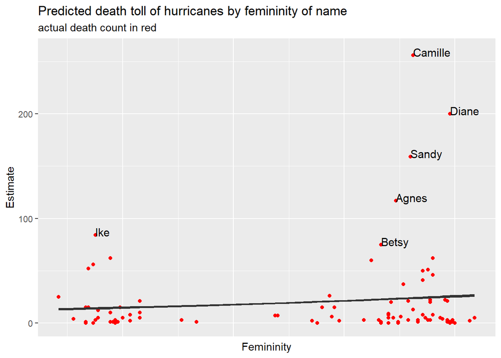

```r
ftd <- fitted(h11.2, probs = c(0.055, 0.945)) %>%
       as_tibble() %>%
       bind_cols(h11.2$data) %>%
       mutate(name = h$name)

ggplot(data = ftd, mapping = aes(x = femininity, y = deaths)) +
      geom_point(color = "red") + geom_line(mapping = aes(x = femininity, y = Estimate),
                                             color = "black") +
      geom_ribbon(mapping = aes(x = femininity, ymin = Q5.5, ymax = Q94.5)) +
      geom_text(aes(label=ifelse(deaths >= 75, as.character(name), '')),
                hjust=0, nudge_y = 3, size = 4) +
      labs(title = "Predicted death toll of hurricanes by femininity of name",
           subtitle = "actual death count in red",
           x = "Femininity", y = "Estimate") +
      theme(axis.text.x=element_blank(),
            axis.ticks.x = element_blank())
```

#### 11H2

```r
#gamma-Poisson/negative binomial model
h11.3 <- brm(data = h, family = negbinomial,
         deaths ~ 1 + femininity,
         prior = c(prior(normal(0, 10), class = Intercept),
              prior(normal(0, 1), class = b)),
         iter = 3000, warmup = 1000, cores = 2, chains = 2)
fixef(h11.3) %>% round(digits = 2)
```

```
##            Estimate Est.Error  Q2.5 Q97.5
## Intercept      2.57      0.38  1.87  3.37
## femininity     0.07      0.05 -0.03  0.16
```

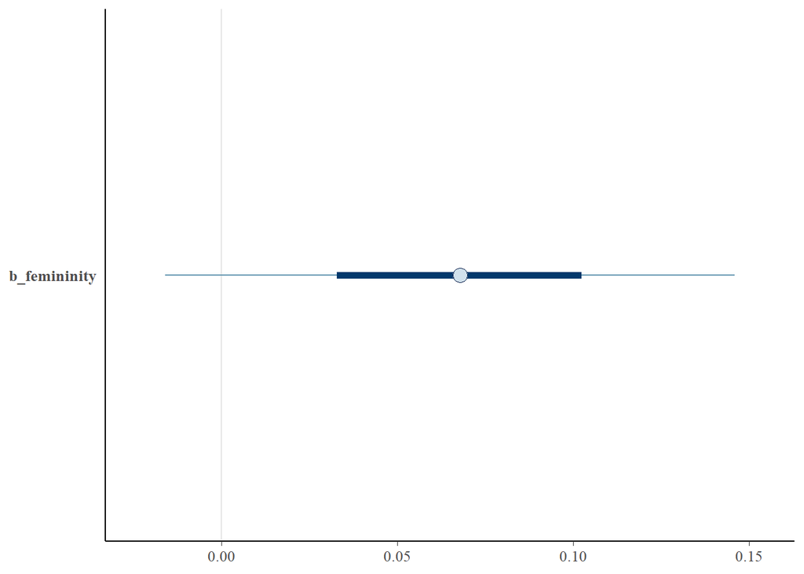

```r
#making coefficient plot
post <- posterior_samples(h11.3)

post %>%
select(-lp__) %>%
  select(b_femininity) %>%
  mcmc_intervals(prob = .5, prob_outer = .89) +
  theme(axis.ticks.y = element_blank(),
        axis.text.y  = element_text(hjust = 0))
```

#### 11H3

```r
#std variables so models will actually run
h <- h %>% mutate(damage_norm_std = (damage_norm - mean(damage_norm))/sd(damage_norm),
                  min_pressure_std = (min_pressure - mean(min_pressure))/sd(min_pressure))

#just damage interaction
h11.4 <- brm(data = h, family = negbinomial,
         deaths ~ 1 + femininity + damage_norm_std + femininity:damage_norm_std,
         prior = c(prior(normal(0, 10), class = Intercept),
              prior(normal(0, 1), class = b)),
         iter = 3000, warmup = 1000, cores = 2, chains = 2)
```

```
## recompiling to avoid crashing R session
```

```r
#just min pressure interaction
h11.5 <- update(h11.4, newdata = h,
                formula = deaths ~ 1 + femininity + min_pressure_std + femininity:min_pressure_std)
#both predictors, one interaction (damage)
h11.6 <- update(h11.4, newdata = h,
                formula = deaths ~ 1 + femininity + damage_norm_std + min_pressure_std +
                femininity:damage_norm_std)
#both predictors, one interaction (pressure)
h11.7 <- update(h11.4, newdata = h,
                formula = deaths ~ 1 + femininity + damage_norm_std + min_pressure_std +
                femininity:min_pressure_std)
#both interactions
h11.8 <- update(h11.4, newdata = h,
                formula = deaths ~ 1 + femininity + damage_norm_std + min_pressure_std +
                femininity:damage_norm_std + femininity:min_pressure_std)
#waic
waic(h11.4, h11.5, h11.6, h11.7, h11.8)
```

```
##                 WAIC    SE
## h11.4         670.15 33.98
## h11.5         693.93 37.98
## h11.6         668.17 37.35
## h11.7         671.82 36.81
## h11.8         664.37 35.78
## h11.4 - h11.5 -23.78 19.15
## h11.4 - h11.6   1.98  9.28
## h11.4 - h11.7  -1.67 12.38
## h11.4 - h11.8   5.78  7.79
## h11.5 - h11.6  25.76 13.20
## h11.5 - h11.7  22.11  9.99
## h11.5 - h11.8  29.57 13.87
## h11.6 - h11.7  -3.65  7.04
## h11.6 - h11.8   3.81  3.77
## h11.7 - h11.8   7.46  8.09
```

```r
#weights
model_weights(h11.4, h11.5, h11.6, h11.7, h11.8,
              weights = "waic") %>%
  round(digits = 2)
```

```
## h11.4 h11.5 h11.6 h11.7 h11.8
##  0.05  0.00  0.12  0.02  0.81
```

```r
fixef(h11.8) %>% round(digits = 2)
```

```
##                             Estimate Est.Error  Q2.5 Q97.5
## Intercept                       2.29      0.30  1.74  2.87
## femininity                      0.04      0.04 -0.04  0.11
## damage_norm_std                -0.18      0.43 -0.97  0.70
## min_pressure_std               -1.04      0.41 -1.84 -0.20
## femininity:damage_norm_std      0.18      0.06  0.06  0.29
## femininity:min_pressure_std     0.08      0.05 -0.01  0.18
```

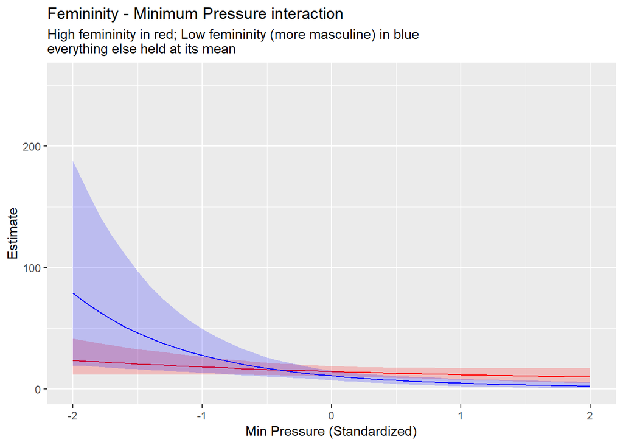

```r
min_press_seq <- seq(from = -2, to = 2, by = 0.1)

  #making feminine and masculine data
  ndf <- tibble(damage_norm_std = 0, min_pressure_std = min_press_seq,
                femininity = quantile(h$femininity, 0.9))
  ndm <- tibble(damage_norm_std = 0, min_pressure_std = min_press_seq,
                femininity = quantile(h$femininity, 0.1))

  #getting fitted results for each of our new data
  fitd_f <-
    fitted(h11.8,
           newdata = ndf,
           probs = c(0.045, 0.945)) %>%
    as_tibble() %>%
    bind_cols(ndf)

  fitd_m <-
    fitted(h11.8,
           newdata = ndm,
           probs = c(0.045, 0.945)) %>%
    as_tibble() %>%
    bind_cols(ndm)

  # making plot
  fig <-
    ggplot() +
    geom_ribbon(data = fitd_f,
                aes(x    = min_pressure_std,
                    ymin = Q4.5,
                    ymax = Q94.5),
                fill = "red", alpha = 1/5) +
    geom_line(data = fitd_f,
              aes(x = min_pressure_std, y = Estimate),
              color = "red") +
    geom_ribbon(data = fitd_m,
                aes(x    = min_pressure_std,
                    ymin = Q4.5,
                    ymax = Q94.5),
                fill = "blue", alpha = 1/5) +
    geom_line(data = fitd_m,
              aes(x = min_pressure_std, y = Estimate),
              color = "blue")+
    scale_x_continuous("Min Pressure (Standardized)", breaks = c(-2, -1, 0, 1, 2)) +
    coord_cartesian(xlim = -2:2,
                    ylim = range(h$deaths)) +
    labs(title = "Femininity - Minimum Pressure interaction",
         subtitle = "High femininity in red; Low femininity (more masculine) in blue\neverything else held at its mean")

  plot(fig)
```

This plot shows that at low minimum pressure, hurricanes with masculine names have a higher estimated death toll than hurricanes with high feminine names, while at high levels of minimum pressure, hurricanes with feminine names have a higher estimated death toll than hurricanes with masculine names. However, the overall trend shown in both the lines for predicted death toll of masculine and feminine named hurricanes is that as minimum pressure increases, the estimated death toll decreases.

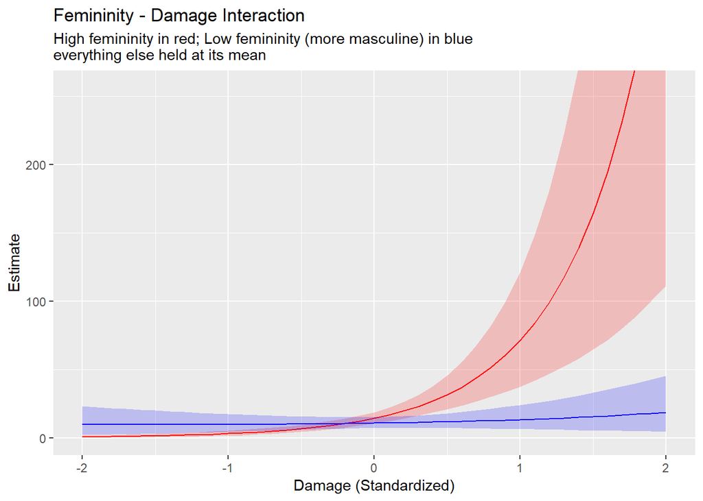

```r
#plotting opposite way
damage_seq <- seq(from = -2, to = 2, by = 0.1)

  ndf <- tibble(damage_norm_std = damage_seq, min_pressure_std = 0,
                femininity = quantile(h$femininity, 0.9))
  ndm <- tibble(damage_norm_std = damage_seq, min_pressure_std = 0,
                femininity = quantile(h$femininity, 0.1))

  fitd_f <-
    fitted(h11.8,
           newdata = ndf,
           probs = c(0.045, 0.945)) %>%
    as_tibble() %>%
    bind_cols(ndf)

  fitd_m <-
    fitted(h11.8,
           newdata = ndm,
           probs = c(0.045, 0.945)) %>%
    as_tibble() %>%
    bind_cols(ndm)

  #plot
  fig <-
    ggplot() +
    geom_ribbon(data = fitd_f,
                aes(x    = damage_norm_std,
                    ymin = Q4.5,
                    ymax = Q94.5),
                fill = "red", alpha = 1/5) +
    geom_line(data = fitd_f,
              aes(x = damage_norm_std, y = Estimate),
              color = "red") +
    geom_ribbon(data = fitd_m,
                aes(x    = damage_norm_std,
                    ymin = Q4.5,
                    ymax = Q94.5),
                fill = "blue", alpha = 1/5) +
    geom_line(data = fitd_m,
              aes(x = damage_norm_std, y = Estimate),
              color = "blue")+
    scale_x_continuous("Damage (Standardized)", breaks = c(-2, -1, 0, 1, 2)) +
    coord_cartesian(xlim = -2:2,
                    ylim = range(h$deaths)) +
    labs(title = "Femininity - Damage Interaction",
         subtitle = "High femininity in red; Low femininity (more masculine) in blue\neverything else held at its mean")

  plot(fig)
```

The interaction between femininity and damage shows a more drastic difference between more and less feminine names. As damage increases, the death toll for feminine names seems to be growing at an exponential rate while for masculine names, there is only a slightly positive relationship between damage and the estimated death toll.

One note of concern is that the difference in death estimate between a name with a high femininity score and a low femininity score is extremely large when damage is also high, reaching well over 100 deaths above a standardized damage score of 1.5. These effect sizes hardly seem plausible, given what we know about hurricanes and how damage itself is related to death toll. It is possible that using the logarithm of storm damage is a better indicator of the relationship between damage and death rate. To test this idea, we can re-estimate this model with log(damage) and see which model performs the best.

#### 11H4

```r
#using log(damage_norm)
h <- h %>% mutate(log_damage = log(damage_norm))

h11.9 <- update(h11.3, newdata = h,
                formula = deaths ~ 1 + femininity + log_damage + min_pressure_std +
                femininity:log_damage + femininity:min_pressure_std)
h11.10 <- update(h11.3, newdata = h,
                formula = deaths ~ 1 + femininity + damage_norm + min_pressure_std +
                femininity:damage_norm + femininity:min_pressure_std)
#waic
waic(h11.8, h11.9, h11.10)
```

```
##                    WAIC      SE
## h11.8            664.37   35.78
## h11.9            636.07   32.03
## h11.10          7064.20 3295.29
## h11.8 - h11.9     28.30   14.03
## h11.8 - h11.10 -6399.83 3287.40
## h11.9 - h11.10 -6428.13 3287.10
```

```r
#weights
model_weights(h11.8, h11.9, h11.10,
              weights = "waic") %>%
  round(digits = 2)
```

```
##  h11.8  h11.9 h11.10
##      0      1      0
```

Because I had estimated the original model with damage standardized, I estimated two new models here: h11.9 which used log(damage) and h11.10, which used damage_norm as it was initially scaled, to compare the fits across multiple scales of the damage variable.

The WAIC for the model with log damage (h11.9) was the lowest, much lower than the model with damage untransformed (h11.10), and slightly lower than the model with damage standardized (h11.8). Indeed, the model with log damage also received all of the weight.

```r
fixef(h11.8) %>% round(digits = 2)
```

```
##                             Estimate Est.Error  Q2.5 Q97.5
## Intercept                       2.29      0.30  1.74  2.87
## femininity                      0.04      0.04 -0.04  0.11
## damage_norm_std                -0.18      0.43 -0.97  0.70
## min_pressure_std               -1.04      0.41 -1.84 -0.20
## femininity:damage_norm_std      0.18      0.06  0.06  0.29
## femininity:min_pressure_std     0.08      0.05 -0.01  0.18
```

```r
fixef(h11.9) %>% round(digits = 2)
```

```
##                             Estimate Est.Error  Q2.5 Q97.5
## Intercept                      -0.81      1.54 -3.88  2.08
## femininity                     -0.15      0.19 -0.50  0.21
## log_damage                      0.42      0.20  0.03  0.83
## min_pressure_std               -0.02      0.46 -0.93  0.88
## femininity:log_damage           0.02      0.02 -0.03  0.07
## femininity:min_pressure_std     0.00      0.05 -0.11  0.10
```

To better understand the model estimates, the interactions between femininity and minimum pressure and femininity and log damage are presented below.

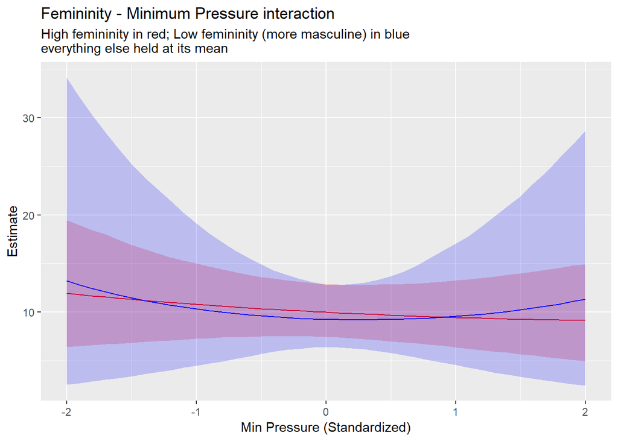

```r
min_press_seq <- seq(from = -2, to = 2, by = 0.1)

  #making feminine and masculine data
  ndf <- tibble(log_damage = mean(h$log_damage), min_pressure_std = min_press_seq,
                femininity = quantile(h$femininity, 0.9))
  ndm <- tibble(log_damage = mean(h$log_damage), min_pressure_std = min_press_seq,
                femininity = quantile(h$femininity, 0.1))

  #getting fitted results for each of our new data
  fitd_f <-
    fitted(h11.9,
           newdata = ndf,
           probs = c(0.045, 0.945)) %>%
    as_tibble() %>%
    bind_cols(ndf)

  fitd_m <-
    fitted(h11.9,
           newdata = ndm,
           probs = c(0.045, 0.945)) %>%
    as_tibble() %>%
    bind_cols(ndm)

  # making plot
  fig <-
    ggplot() +
    geom_ribbon(data = fitd_f,
                aes(x    = min_pressure_std,
                    ymin = Q4.5,
                    ymax = Q94.5),
                fill = "red", alpha = 1/5) +
    geom_line(data = fitd_f,
              aes(x = min_pressure_std, y = Estimate),
              color = "red") +
    geom_ribbon(data = fitd_m,
                aes(x    = min_pressure_std,
                    ymin = Q4.5,
                    ymax = Q94.5),
                fill = "blue", alpha = 1/5) +
    geom_line(data = fitd_m,
              aes(x = min_pressure_std, y = Estimate),
              color = "blue")+
    scale_x_continuous("Min Pressure (Standardized)", breaks = c(-2, -1, 0, 1, 2)) +
    coord_cartesian(xlim = -2:2) +
    labs(title = "Femininity - Minimum Pressure interaction",
         subtitle = "High femininity in red; Low femininity (more masculine) in blue\neverything else held at its mean")

  plot(fig)
```

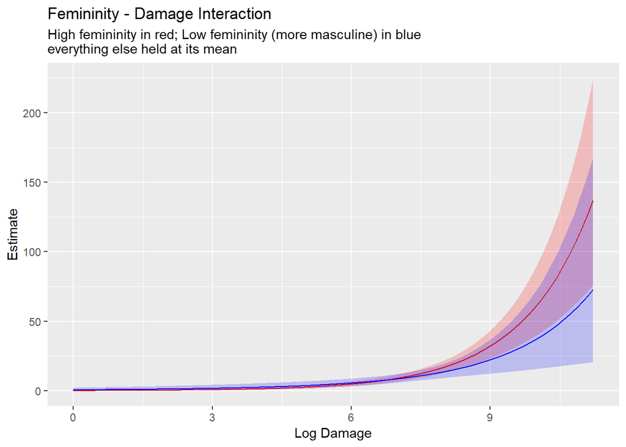

```r
#plotting opposite way
damage_seq <- seq(from = min(h$log_damage), to = max(h$log_damage), by = 0.01)

  ndf <- tibble(log_damage = damage_seq, min_pressure_std = 0,
                femininity = quantile(h$femininity, 0.9))
  ndm <- tibble(log_damage = damage_seq, min_pressure_std = 0,
                femininity = quantile(h$femininity, 0.1))

  fitd_f <-
    fitted(h11.9,
           newdata = ndf,
           probs = c(0.045, 0.945)) %>%
    as_tibble() %>%
    bind_cols(ndf)

  fitd_m <-
    fitted(h11.9,
           newdata = ndm,
           probs = c(0.045, 0.945)) %>%
    as_tibble() %>%
    bind_cols(ndm)

  #plot
  fig <-
    ggplot() +
    geom_ribbon(data = fitd_f,
                aes(x    = log_damage,
                    ymin = Q4.5,
                    ymax = Q94.5),
                fill = "red", alpha = 1/5) +
    geom_line(data = fitd_f,
              aes(x = log_damage, y = Estimate),
              color = "red") +
    geom_ribbon(data = fitd_m,
                aes(x    = log_damage,
                    ymin = Q4.5,
                    ymax = Q94.5),
                fill = "blue", alpha = 1/5) +
    geom_line(data = fitd_m,
              aes(x = log_damage, y = Estimate),
              color = "blue")+
    labs(title = "Femininity - Damage Interaction",
         subtitle = "High femininity in red; Low femininity (more masculine) in blue\neverything else held at its mean",
         x = "Log Damage")

  plot(fig)
```

Similarly, the difference in hurricanes with names high in femininity and low in femininity as log damage increases is much less drastic than it was in the previous model’s estimates. It does appear that at very high levels of log damage, highly feminine-named hurricanes have a higher estimated death toll, but the effect is not very large at all.

Overall, I believe that there is not a relationship between femininity and deaths of hurricanes. While initial analyses did find an effect, accounting for overdispersion and correctly scaling parameters reduced these effects enough such that the estimate for the effect of femininity included 0 in its 95% confidence interval, and even the relationships between the log amount of damage and femininity as well as minimum pressure and femininity did not show a large difference between feminine and masculine named hurricanes.

#### 11H5

```r
data("Trolley")
t <- Trolley
t <- t %>% mutate(edbin = ifelse(edu == "High School Graduate" |
                                 edu == "Some College"|
                                 edu == "Bachelor's Degree" |
                                 edu == "Master's Degree" |
                                 edu == "Graduate Degree", 1, 0))

inits <- list(`Intercept[1]`      = -1.9,
              `Intercept[2]`      = -1.2,
              `Intercept[3]`      = -0.7,
              `Intercept[4]`      =  0.2,
              `Intercept[5]`      =  0.9,
              `Intercept[6]`      =  1.8,
               contact            =  0,
               male               =  0,
              `contact:male` =  0)

h11.11 <- brm(data = t, family = cumulative,
          response ~ 1 + contact + male + contact:male,
          prior = c(prior(normal(0, 10), class = Intercept),
                    prior(normal(0, 10), class = b)),
          iter = 2000, warmup = 1000, cores = 2, chains = 2,
          inits = list(inits, inits))
# Start values for h11.12
inits <- list(`Intercept[1]`      = -1.9,
              `Intercept[2]`      = -1.2,
              `Intercept[3]`      = -0.7,
              `Intercept[4]`      =  0.2,
              `Intercept[5]`      =  0.9,
              `Intercept[6]`      =  1.8,
              contact             =  0,
              age                 = 0,
              edbin                = 0,
              `contact:intention` =  0)

h11.12 <- update(h11.11, newdata = t,
                 formula = response ~ 1 + contact + male + contact:male + age + edbin,
                 inits = list(inits, inits))
#start values for h11.13
inits <- list(`Intercept[1]`      = -1.9,
              `Intercept[2]`      = -1.2,
              `Intercept[3]`      = -0.7,
              `Intercept[4]`      =  0.2,
              `Intercept[5]`      =  0.9,
              `Intercept[6]`      =  1.8,
              action              =  0,
              intention           =  0,
              contact             =  0,
              age                 = 0,
              edbin                = 0,
              `contact:intention` =  0)

h11.13 <- update(h11.11, newdata = t,
                 formula = response ~ 1 + contact + male + contact:male + age + edbin +
                           intention + action)
#waic
waic(h11.11, h11.12, h11.13)
```

```
##                     WAIC    SE
## h11.11          37445.95 70.11
## h11.12          37436.48 70.40
## h11.13          36825.57 82.61
## h11.11 - h11.12     9.46  6.94
## h11.11 - h11.13   620.38 50.19
## h11.12 - h11.13   610.91 49.48
```

```r
#weights
model_weights(h11.11, h11.12, h11.13,
              weights = "waic") %>%
  round(digits = 2)
```

```
## h11.11 h11.12 h11.13
##      0      0      1
```

One hypothesis of gender differences in moral reasoning suggests that women are more morally-averse to inflicting harm (or more morally concerned with care) than men are. To assess this hypothesis, cumulative logit models were estimated assessing the relationship between gender, contact, gender*contact, and the likelihood of each response on a likert scale from 1-7 with lower numbers indicating less moral acceptability. Model h11.11 has only these variables, while h11.12 adds some control variables (age and a binary variable indicating whether or not a respondent graduated from high school), and the third adds both intention and action to the model with the other variables to account for the possibility that other aspects of the moral narrative affect the effect of contact and response.

According to the WAIC values, model h11.13, the one with the contact, gender, controls, and intention and action, fit the data best. Correspondingly, it received all of the weight. Consequently, this model will be the one used to evaluate the relationship between gender, contact, and moral acceptability.

```r
fixef(h11.13) %>% round(digits = 2)
```

```
##              Estimate Est.Error  Q2.5 Q97.5
## Intercept[1]    -2.82      0.09 -2.99 -2.64
## Intercept[2]    -2.13      0.09 -2.31 -1.96
## Intercept[3]    -1.54      0.09 -1.72 -1.37
## Intercept[4]    -0.49      0.09 -0.67 -0.33
## Intercept[5]     0.19      0.09  0.02  0.36
## Intercept[6]     1.12      0.09  0.95  1.30
## contact         -0.86      0.07 -1.00 -0.72
## male             0.60      0.04  0.52  0.68
## age              0.00      0.00 -0.01  0.00
## edbin           -0.13      0.08 -0.29  0.02
## intention       -0.73      0.04 -0.80 -0.66
## action          -0.72      0.04 -0.80 -0.64
## contact:male    -0.21      0.09 -0.39 -0.04
```

The main effect of contact is negative, and its 95% interval does not contain zero, which matches what we’d expect: a version of the trolley problem including direct contact is expected to decrease the moral acceptability by 0.86 points on the likert scale. The main effect for male is positive, and its 95% interval also does not contain zero. This suggests that men generally find trolley problem questions more morally permissible than women by 0.6 points on the scale. The interaction between contact and male is negative, and its 95% interval similarly does not contain zero. Interestingly, this suggests the opposite relationship than the hypothesis: there is a stronger relationship for men than women in the decrease of moral permissibility of a trolley problem vignette when the vignette includes contact.

This interaction is depicted below, using the mean response across genders to help with visualization.

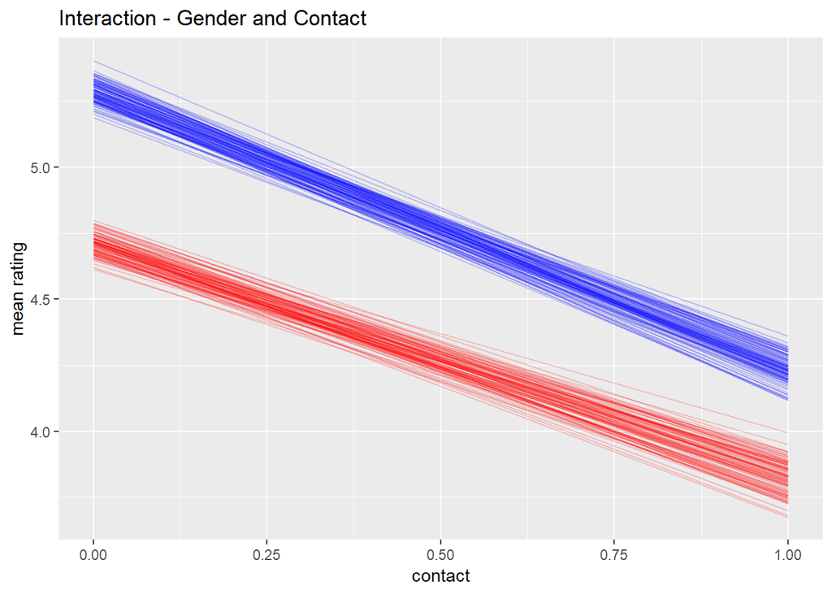

```r
#function to get the data needed for plot when male or female
plot_data <- function(male, max_iter){

  nd <-
    tibble(contact    = c(0, 1),
           male   = male,
           intention = 0,
           action = 0,
           edbin = 1,
           age = mean(t$age))

  max_iter <- max_iter

  fitted(h11.13,
         newdata = nd,
         subset  = 1:max_iter,
         summary = F) %>%
    as_tibble() %>%
    gather() %>%
    mutate(iter = rep(1:max_iter, times = 14)) %>%
    select(iter, everything()) %>%
    separate(key, into = c("contact", "rating")) %>%
    mutate(contact = contact %>% as.double(),
           rating    =  rating %>% as.double()) %>%
    mutate(contact = contact -1) %>%
    rename(pk = value) %>%
    mutate(`pk:rating` = pk * rating) %>%
    group_by(iter, contact) %>%

    summarise(mean_rating = sum(`pk:rating`))
}

p1 <- plot_data(male = 1,
                max_iter = 100)
p2 <- plot_data(male = 0,
                max_iter = 100)

ggplot(data = p1, mapping = aes(x = contact, y = mean_rating, group = iter)) +
       geom_line(alpha = 0.2, color = "blue") +
       geom_line(data = p2, mapping = aes(x = contact, y = mean_rating, group = iter),
                 alpha = 0.2, color = "red") +
       labs(title = "Interaction - Gender and Contact",
            x = "contact",
            y = "mean rating")
```

While women do find vignettes with contact less morally acceptable than men do, the slope of the line is flatter. There is less of a decrease in acceptability of a trolley problem associated with the inclusion of contact than there is for men. This suggests that men actually have a more strongly negative moral perception of the acceptability of harm.

#### 11H6

```r
data(Fish)
f <- Fish

f <- f %>% mutate(log_hours = log(hours))

h11.14 <-
  brm(data = f, family = zero_inflated_poisson,
      bf(fish_caught ~ 1 + livebait + offset(log_hours), zi ~ persons),
      prior = c(prior(normal(0, 10), class = Intercept),
                prior(normal(0, 10), class = b)),
      cores = 4)
h11.15 <- update(h11.14, newdata = f,
                 formula. = bf(fish_caught ~ 1 + livebait + offset(log_hours), zi ~ child ))
```

```
## Replacing initial definitions of parameters 'zi'
```

```r
h11.16 <- update(h11.14, newdata = f,
                 formula. = bf(fish_caught ~ 1 + livebait + offset(log_hours),
                               zi ~ child + persons))
```

```
## Replacing initial definitions of parameters 'zi'
```

```r
h11.17 <-
  brm(data = f, family = zero_inflated_poisson,
      bf(fish_caught ~ 1 + livebait + child + persons + offset(log_hours),
         zi ~ persons),
      prior = c(prior(normal(0, 10), class = Intercept),
                prior(normal(0, 10), class = b)),  # the brms default is beta(1, 1)
      cores = 4)
```

```
## recompiling to avoid crashing R session
```

```r
h11.18 <- update(h11.17, newdata = f,
                 formula = bf(fish_caught ~ 1 + livebait + child + persons + offset(log_hours),
                              zi ~ persons + child))
```

```
## Replacing initial definitions of parameters 'zi'
```

```r
waic(h11.14, h11.15, h11.16, h11.17, h11.18)
```

```
##                    WAIC     SE
## h11.14          2458.53 449.22
## h11.15          2504.05 454.10
## h11.16          2466.09 451.35
## h11.17          2126.03 390.27
## h11.18          2129.90 390.76
## h11.14 - h11.15  -45.52  12.05
## h11.14 - h11.16   -7.55   3.70
## h11.14 - h11.17  332.51 210.38
## h11.14 - h11.18  328.64 209.90
## h11.15 - h11.16   37.97  11.45
## h11.15 - h11.17  378.03 213.05
## h11.15 - h11.18  374.16 212.55
## h11.16 - h11.17  340.06 212.04
## h11.16 - h11.18  336.19 211.49
## h11.17 - h11.18   -3.87   9.23
```

```r
#weights
model_weights(h11.14, h11.15, h11.16, h11.17, h11.18,
              weights = "waic") %>%
  round(digits = 2)
```

```
## h11.14 h11.15 h11.16 h11.17 h11.18
##   0.00   0.00   0.00   0.87   0.13
```

In assessing the number of fish an average visitor catches per hour in the national park, a zero-inflated model should be estimated because not every visitor even attempted fishing. To fit this model, I ran a few combinations of different predictors and then assessed the model fit across possible models. I chose model h11.17 to evaluate estimates becase it had the highest weight and lowest WAIC.

```r
fixef(h11.17) %>% round(digits = 2)
```

```
##              Estimate Est.Error  Q2.5 Q97.5
## Intercept       -3.69      0.28 -4.27 -3.15
## zi_Intercept     0.88      0.61 -0.27  2.07
## livebait         1.49      0.25  1.02  2.01
## child            0.49      0.08  0.32  0.66
## persons          0.66      0.04  0.58  0.75
## zi_persons      -1.03      0.30 -1.67 -0.48
```

The portion of the zero-inflated Poisson that predicts the probability of a person not fishing are the estimates beginning with zi. The model predicts that a group with 1 person does not fish 46.2570155 percent of the time. With 2 people, the group has a probability of 0.23of not fishing.

To visualize these relationships, the marginal effects are plotted below.

Marginal effects:

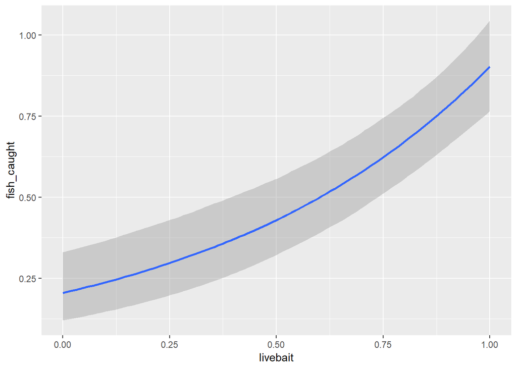

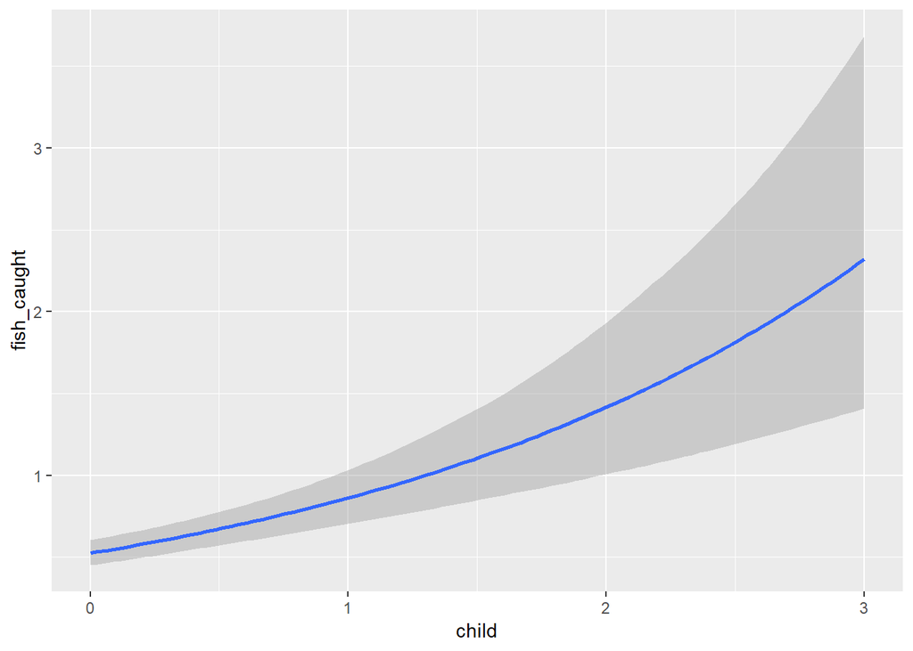

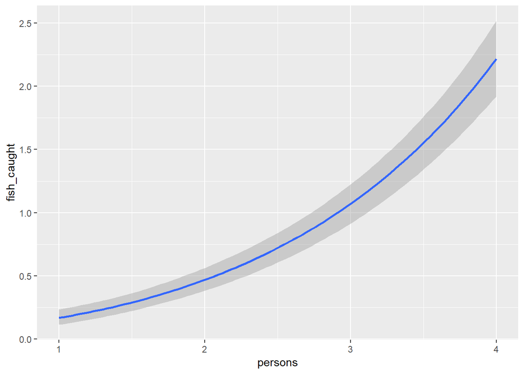

```r
plot(marginal_effects(h11.17), ask = FALSE)
```